# Differential gene expression analysis in R

Akhil, Marian & Mallik

2022-05-30

```r
##loading necessary libraries
library(tidyverse)
library(data.table)
library(waldo)
library(readxl)
library(edgeR)
library(DESeq2)
library(adegenet)
library(RColorBrewer)
library(adegenet)
library(ade4)
library(factoextra)
library(UpSetR)
library(ggvenn)
library(VennDetail)
library(affy)

##set up working directory
setwd("C:/Akhil_Pashapu/PhD/Workshop")
```

The counts martix file generated from abundance_estimates_to_matrix.pl (from Trinity pipeline) or the corset count matrix can be used for Differential expression analysis. Due to lots of redundancy in De novo assembly it is better to use corset counts matrix

It is very important to design the experimantal setup to answer the relevant biological questions. In the current study two Timothy (Phleum pretensis. L) cultivars Engmo (Northern adapted), Grindstad (southern adapted) are subjected to freezing tests to find differentially expressed genes due to cold treatment and find genes which responded differently to cold between the two cultivar.

```r
#loding counts matrix file
dta<- read.table("counts.txt", header = T)
names(dta)
```

```
## [1] "S1"  "S49" "S2"  "S38" "S7"  "S43" "S8"  "S44"
```

```r
#creating metadata for the counts
mdta<-data.frame(id=c('S1','S49','S2','S38','S7','S43','S8','S44'),
                 sample=c('1EK','2EK','1ET','2ET','1GK','2GK','1GT','2GT'),
                 rep=c(1,2,1,2,1,2,1,2),
                 group1=c('EK','EK','ET','ET','GK','GK','GT','GT'),
                 cultivar=c('Engmo','Engmo','Engmo','Engmo','Grindstad','Grindstad','Grindstad','Grindstad'),
                 treatment=c('K','K','T','T','K','K','T','T'),
                 stringsAsFactors = TRUE)

rownames(mdta)<-mdta$id
```

The edgeR stores the count data & metadata data in DEGList object. Before creating the DEGList make sure the rownames in metadata & the column names in counts matrix are in same order

```r
##checking the order of samples in metadata and count data
waldo::compare(colnames(dta), rownames(mdta)) # no differences will output "✔ No differences"
```

```
## v No differences
```

```r
#preparing DEGlist
FtDEG<-DGEList(counts = dta, samples = mdta, remove.zeros = T )
dim(FtDEG) # no. of rows(transcripts) & columns(samples)
```

```
## [1] 99660     8
```

Genes with low counts across different samples in the experiments provide very little to no information. For a gene to be considered biologically relevant, it should be expressed at least at a minimal level. The low read counts also skew the data distribution and decreases the statistical power during the downstream analysis. Lets plot the log(cpm) values of raw reads to see the distribution

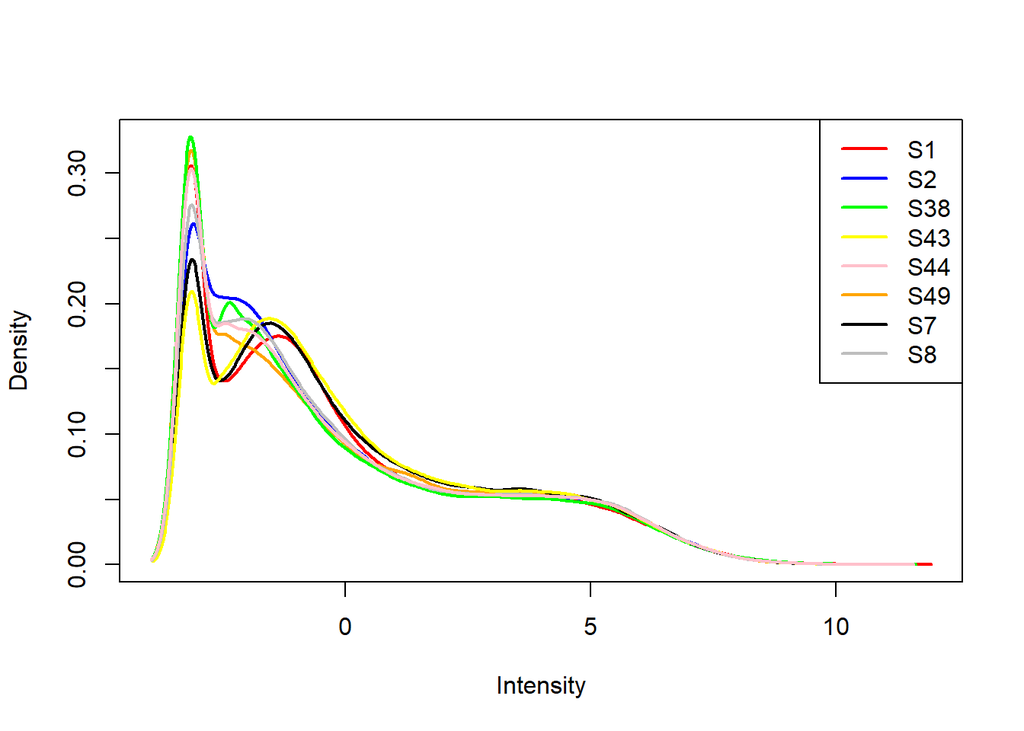

```r
##plotting distribution of counts
plotDensities(cpm(FtDEG$counts, log = T),col = c("red", "blue", "green", "yellow", "pink", "orange","black", "gray"), legend = "topright")
```

.  
We can see many transcripts are with low count values, so we filter them out by the function *filterByExpr* from edgeR package. This functions uses cpm values (which account for lib size differences) to filter out counts with low values

```r
##Filtering transcripts with low read counts
keep<-filterByExpr(FtDEG,min.count=10, group = FtDEG$samples$group1 )
table(keep)
```

```
## keep
## FALSE  TRUE
## 43268 56392
```

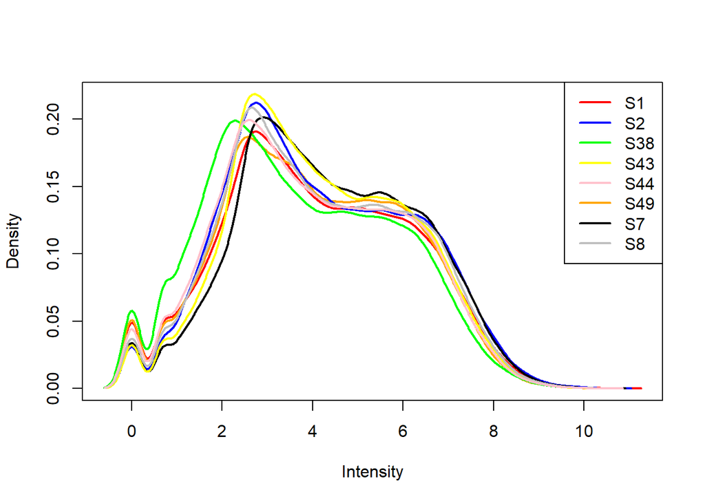

```r
FtDEG <- FtDEG[keep, ,keep.lib.sizes=FALSE]
plotDensities(log(FtDEG$counts),col = c("red", "blue", "green", "yellow", "pink", "orange","black", "gray"), legend = "topright" )
```

.  
Lets check the library sizes of each sample & counts per each transcript after filtering

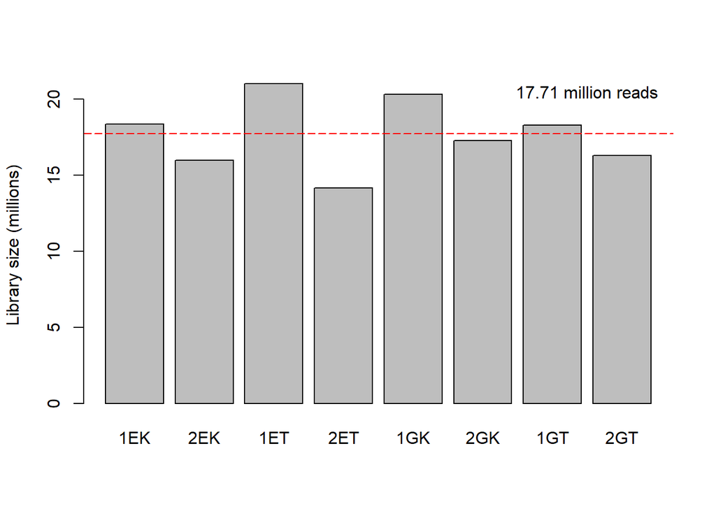

```
## numeric(0)
```

```r
#mean lib.size
lib.size<-as.character(round(mean(FtDEG$samples$lib.size * 1e-6), 2))
#plotting library sizes
barplot(FtDEG$samples$lib.size*1e-6, names=FtDEG$samples$sample, ylab="Library size (millions)")+abline(h=mean(FtDEG$samples$lib.size*1e-6) , col="Red", lty=5, lwd=1)+
  text(x=8.5, y=20.5, paste(lib.size, "million reads", sep = " ") , col= "black")
```

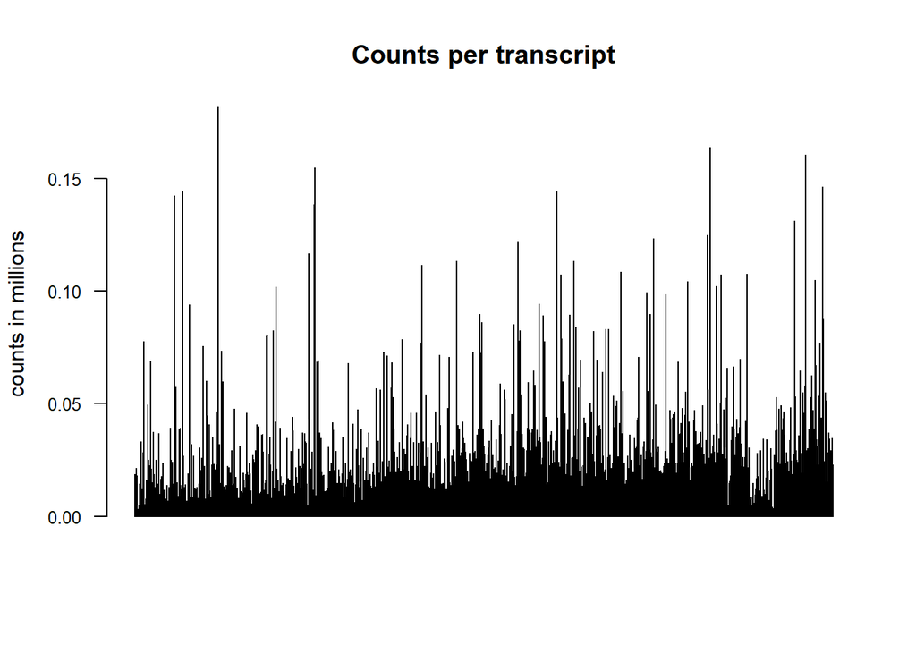

```r
#plotting transcripts counts
barplot(rowSums(FtDEG$counts*1e-6), las=2, main="Counts per transcript", axisnames = FALSE,  ylab = "counts in millions", cex.axis=0.8)
```

.  
The library size bar plot clearly shows there are differences in library sizes we have to account for that before running the DGE analysis. This can be done by the function *calcNormFactors* from edgeR package

```r
#normalization
FtDEG<- calcNormFactors(FtDEG, method = "TMM")
FtDEG$samples
```

```
##     group lib.size norm.factors  id sample rep group1  cultivar treatment
## S1     EK 18346852    0.9333040  S1    1EK   1     EK     Engmo         K
## S49    EK 15965060    1.0199518 S49    2EK   2     EK     Engmo         K
## S2     ET 21011579    0.9466643  S2    1ET   1     ET     Engmo         T
## S38    ET 14167788    0.8842367 S38    2ET   2     ET     Engmo         T
## S7     GK 20325521    1.1000389  S7    1GK   1     GK Grindstad         K
## S43    GK 17270568    1.1450686 S43    2GK   2     GK Grindstad         K
## S8     GT 18271372    1.0123053  S8    1GT   1     GT Grindstad         T
## S44    GT 16287876    0.9841961 S44    2GT   2     GT Grindstad         T
```

Count data is not normally distributed, so to examine the distributions of raw counts we need to log the counts. We’ll use box plots to check the distribution of the read counts to see how samples differ from each other

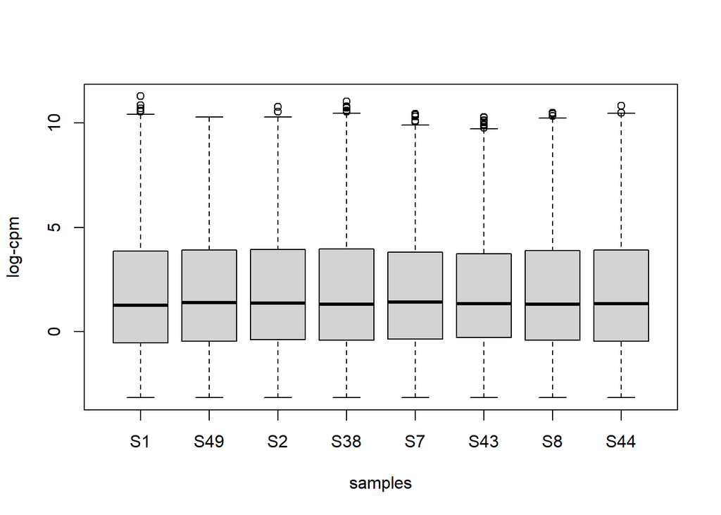

```r
#logcpm values
lcpm <- cpm(FtDEG, prior.count = 2, log=TRUE)
boxplot(lcpm, xlab= "samples", ylab= "log-cpm")
```

.  
Now lets proceed to identify any outliers samples. For that we will use variance stabilizing transformation of raw counts data. Function *vst* from DEseq2 can be used to transform the data. After transforming the data we will use hierarchical clustering to see if biological replicates are clustered together.

```r
## Variance Stablizing transformation
vsd<- vst(round(FtDEG$counts), blind = T) #default blind=T(for totally unsupervised clustering)
```

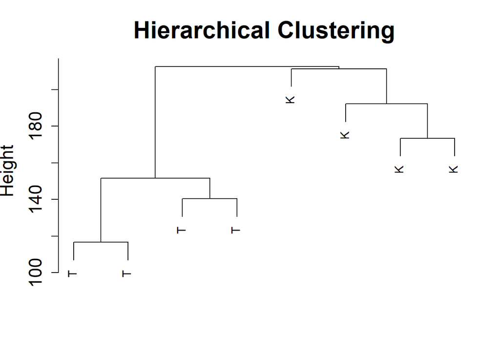

```r
## Hierarchical Clustering
sampleTree<-hclust(dist(t(vsd)))
plot(sampleTree, labels=FtDEG$samples$treatment, main = "Hierarchical Clustering", sub="", xlab="", cex.lab = 1.5,cex.axis = 1.5, cex.main = 2)
```

.  
In the above plot we see the samples are clustered into two groups based on the treatment and there are no outliers. To further investigate we can use the correlations between samples

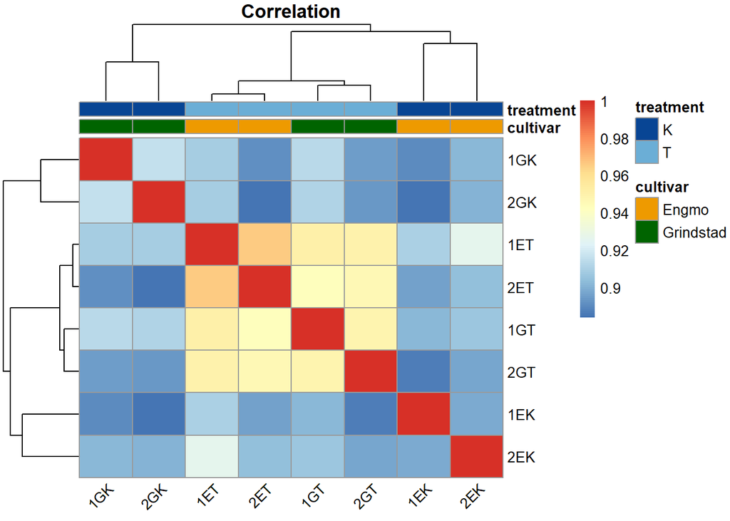

```r
# compute pairwise correlations
vsd_cor <- cor(vsd)

#assigning colors
ann_colors = list(
  cultivar = c(Engmo = "orange2",  Grindstad= "darkgreen"),
  treatment = c(K = "#084594", T = "#6BAED6" ))

#plotting correlation heatmap
pheatmap::pheatmap(vsd_cor, clustering_distance_rows="correlation",clustering_distance_cols = "correlation",
                   annotation = mdta[,c(5,6)], labels_row = mdta$sample, labels_col = mdta$sample,
                   annotation_colors = ann_colors,angle_col = 45, main ="Correlation")
```

.  
To validate our experimental design we can use PCA or any other dimensionality reductions techniques. Instead to using all transcripts we use top 500 highly variable genes

```r
#############################################
# transpose vst count matrix
vsdt<-t(vsd)

#calculating the variance of the logcounts
var_genes <- apply(vsdt, 2, var)

# sorting & picking top 500 highly variable genes for plotting
select_var <- names(sort(var_genes, decreasing=TRUE))[1:500]

# extracting 500 highly variable transcripts from vst matrix
vsdpc <- vsdt[,select_var]

#principle component analysis
pc<-dudi.pca(vsdpc, center=T, scale=F, scannf=F, nf=6)
summary(pc) #Projected inertia (%) is the variance explained by each pc axis
```

```
## Class: pca dudi
## Call: dudi.pca(df = vsdpc, center = T, scale = F, scannf = F, nf = 6)
##
## Total inertia: 1642
##
## Eigenvalues:
##     Ax1     Ax2     Ax3     Ax4     Ax5
##   718.7   283.7   218.1   163.3   121.9
##
## Projected inertia (%):
##     Ax1     Ax2     Ax3     Ax4     Ax5
##  43.764  17.275  13.284   9.942   7.423
##
## Cumulative projected inertia (%):
##     Ax1   Ax1:2   Ax1:3   Ax1:4   Ax1:5
##   43.76   61.04   74.32   84.27   91.69
##
## (Only 5 dimensions (out of 7) are shown)
```

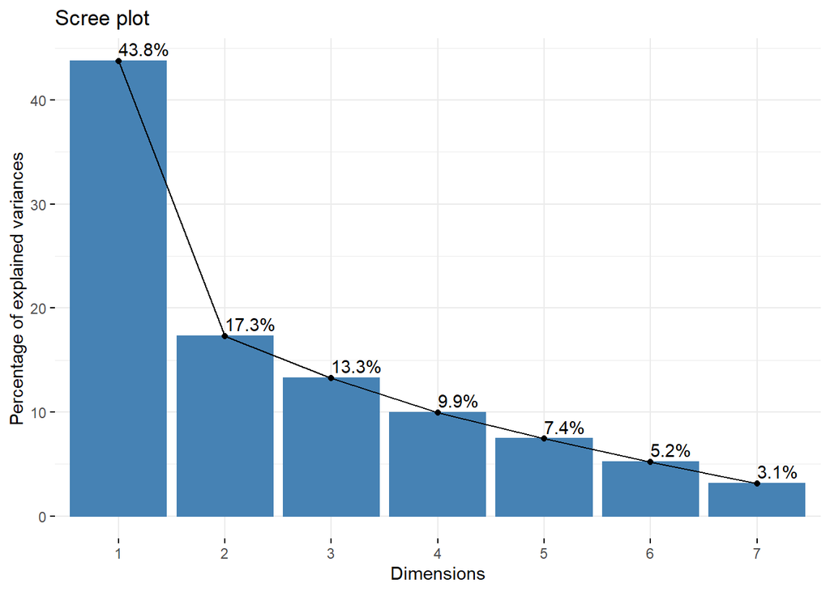

```r
#visualize the % of variance explained by each principle components
fviz_eig(pc, addlabels = T)
```

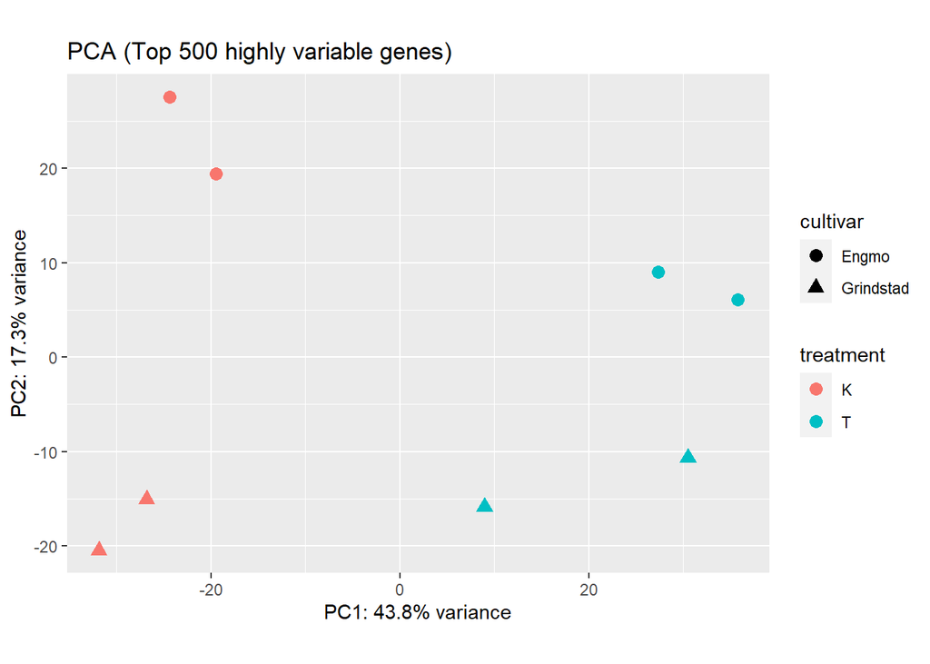

```r
#adding metadata for principle components
pcaData<-as.data.frame(pc$li[,1:6])
pcaData$group<-FtDEG$samples$group1[match(rownames(pcaData), rownames(FtDEG$samples))]
pcaData$cultivar <- FtDEG$samples$cultivar[match(rownames(pcaData), rownames(FtDEG$samples))]
pcaData$treatment <- FtDEG$samples$treatment[match(rownames(pcaData), rownames(FtDEG$samples))]

#plotting
ggplot(pcaData, aes(x = Axis1, y = Axis2, color = treatment, shape = cultivar )) +
  geom_point(size =3)+
  xlab("PC1: 43.8% variance") +
  ylab("PC2: 17.3% variance") +
  coord_fixed() +
  ggtitle("PCA (Top 500 highly variable genes)")
```

The above PCA plot validates our experimental design. The PC1 (x-axis) explaining 44% of variations is separating the control and treated (cold treatment) samples, while the PC2 explaining 17% is separating the two timothy cultivars in this study. The identified sources of variation should be accounted while performing Differential expression analysis.

```r
#model matrix
design<-model.matrix(~ 0+group1,FtDEG$samples) # using grouped variable (treatment & cultivar)
colnames(design)<-levels(FtDEG$samples$group1)

# estimating common dispersion
FtDEG<- estimateGLMCommonDisp(FtDEG, design = design)
FtDEG<- estimateGLMTrendedDisp(FtDEG, design = design)
FtDEG<- estimateGLMTagwiseDisp(FtDEG, design = design)

#biological coefficient of variance
sqrt(FtDEG$common.dispersion) #0.59
```

```
## [1] 0.5949836
```

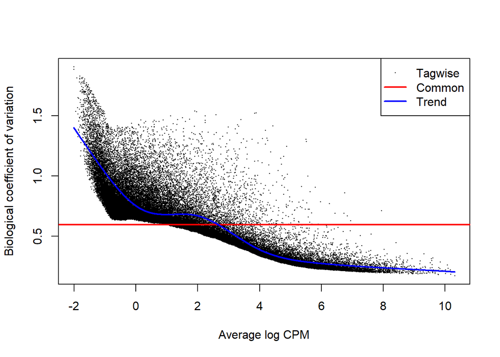

```r
plotBCV(FtDEG)
```

The biological replicates used in this study are not identical/clones, rather they belong to a population, that is one of reason for having moderately high biological coefficient of variation (0.59). We observe decrease in bvc with increase in cpm values and high bvc in genes with low counts.

Lets use the function *makeContrasts* from edgeR to explicitly make all contrasts of interest. This way it is easy to understand and interpret the contrasts. Lets fit the linear model.

```r
# making contrasts
my_contrasts<- makeContrasts(eT_eK = ET-EK,           # DEG due to treatment in engmo
                             gT_gK = GT-GK,           # DEG due to treatment in grindstad
                             egT_egK=(ET-EK)-(GT-GK), # genes which responded differently to treatment(cold) in cultivars
                             levels = design)
# glm fit
fit <- glmFit(FtDEG, design)
```

We can now extract the differentially expressed genes due to cold treatment in Engmo. The function *glmLRT* fits a negative binomial generalized log-linear model to the read counts and conducts statistical testing for the given contrast. We see that a total of 1482 and 289 genes are up-regulated & down regulated respectively in treated sample compared to control.

```r
# differentially expressed genes due to treatment in engmo
fitLRT<-glmLRT(fit,contrast = my_contrasts[,1])
summary(decideTests(fitLRT,p.value = 0.05))
```

```
##        -1*EK 1*ET
## Down          289
## NotSig      54621
## Up           1482
```

The above *glmLRT* function identifies genes as differentially expressed only based on statistical method regardless of how small the differences between groups. If the goal is to find DEG above certain level/threshold, the logFC values could be used to rank genes to identify genes which are up-regulated or down regulated over a certain level. The function *glmTreat* can be used for this purpose, it comes with an option to specify the log fold change.

```r
fit1<-glmTreat(fit,contrast = my_contrasts[,1],lfc = log2(1.2))
summary(decideTests(fit1,p.value = 0.05))
```

```
##        -1*EK 1*ET
## Down          233
## NotSig      54816
## Up           1343
```

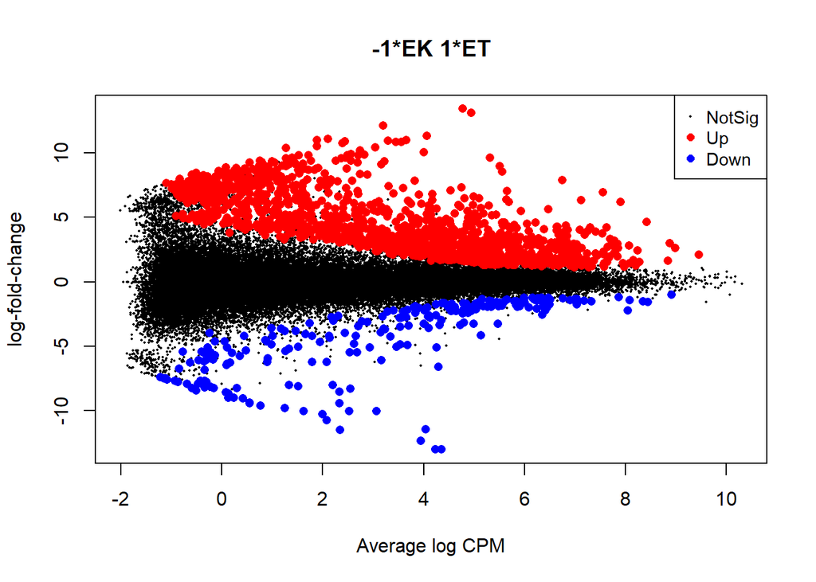

```r
#decideTests(fit1,p.value = 0.05)
eT_eK<-topTags(fit1, n=nrow(FtDEG), adjust.method = "fdr", p.value = 0.05)$table %>% rownames_to_column("GeneID")
write.table(eT_eK ,file = "Engmo_Trt_crtl.txt", col.names = T , row.names = F, quote = F)
plotMD(fit1)
```

Lets find the DEG in the other contrasts

```r
# differentially expressed genes due to treatment in Grindstad
fit2<-glmTreat(fit,contrast = my_contrasts[,2],lfc = log2(1.2))
summary(decideTests(fit2,p.value = 0.05))
```

```
##        -1*GK 1*GT
## Down          536
## NotSig      54333
## Up           1523
```

```r
gT_gK<-topTags(fit2, n=nrow(FtDEG), adjust.method = "fdr", p.value = 0.05)$table %>% rownames_to_column("GeneID")
write.table(gT_gK,file = "Grindstad_Trt_ctrl.txt", col.names = T , row.names = F)
#plotMD(fit2)
```

```r
# genes which responded differently to treatment(cold) in engmo and grindstad
fit3<-glmTreat(fit,contrast = my_contrasts[,3],lfc = log2(1.2))
summary(decideTests(fit3,p.value = 0.05))
```

```
##        -1*EK 1*ET 1*GK -1*GT
## Down                     153
## NotSig                 55806
## Up                       433
```

```r
egT_egK<-topTags(fit3, n=nrow(FtDEG), adjust.method = "fdr", p.value = 0.05)$table %>% rownames_to_column("GeneID")
write.table(egT_egK,file = "Engmo_Grindsatd_Trt_crtl.txt", col.names = T , row.names = F)
#plotMD(fit3)
```

The overlap of DEG due to cold treatment between engmo and grindstad we can be visualized by venn diagram. The overlapd genes between the first two contrasts could be the universal cold response genes.

```r
# universal genes responding to cold treatment
sum(eT_eK$GeneID %in% gT_gK$GeneID)
```

```
## [1] 707
```

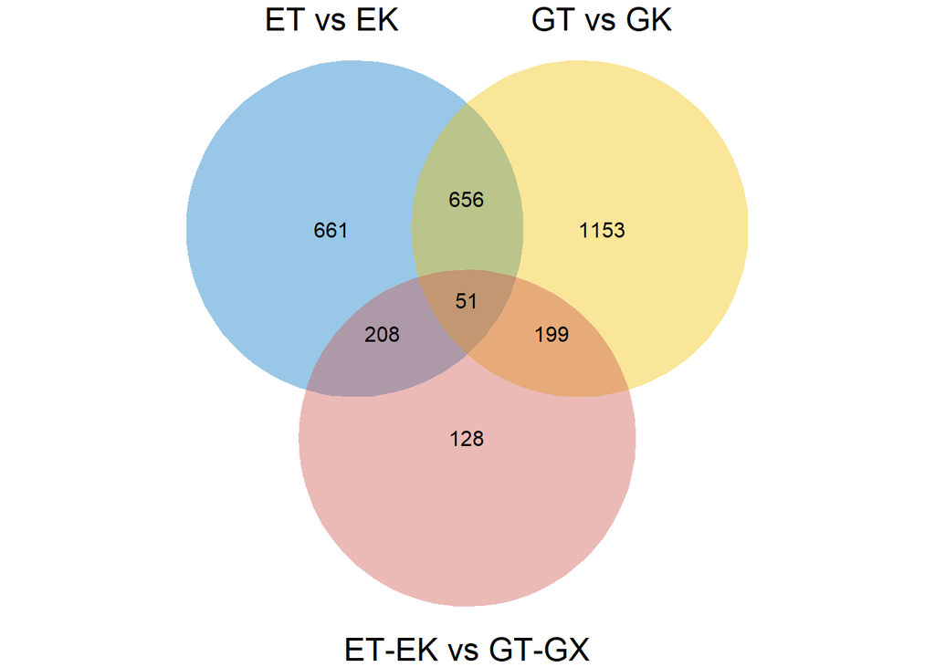

```r
# venn plot
x= list("ET vs EK"= eT_eK$GeneID, "GT vs GK"= gT_gK$GeneID, "ET-EK vs GT-GX"=egT_egK$GeneID)
ggvenn(x, fill_color = c("#0073C2FF", "#EFC000FF", "#CD534CFF"),show_percentage = F,fill_alpha = 0.4,
   set_name_size = 6,stroke_color = "black",stroke_linetype=0)
```

If you want to find overlapping between five or more contrasts upset plot is the way

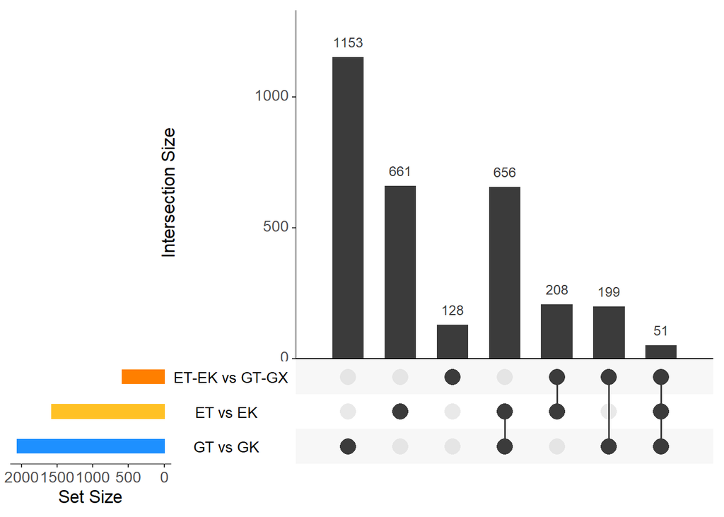

```r
# upset plot
ven <- venndetail(list("ET vs EK"= eT_eK$GeneID, "GT vs GK"= gT_gK$GeneID, "ET-EK vs GT-GX"=egT_egK$GeneID))
plot(ven, type = "upset")
```